# Critical atmospheric events and it’s health and economic impact

fprandini

3/31/2021

```r
## Prepare the environment
setwd("/Volumes/GoogleDrive/My Drive/JohnHopkinsDataScience/datasciencecoursera/5_REPDATA/RepData_PeerAssessment2")
##Avoid scientific notation
options (scipen = 999)
##load libraries
library(dplyr)
```

```r
library(ggplot2)
library(stringr)
library(gridExtra)
library(reshape2)
```

## Synopsis

The objective of this analysis is to provide an overview of the most impactful atmospheric events that occurred in US from 1950 to 2011. To achieve this we will use the NOAA storms database and investigate the impact by event types breaking it down into 2 questions:

- Across the United States, which types of events are most harmful with respect to population health?
- Across the United States, which types of events have the greatest economic consequences?

We have found that **tornadoes** account for the event type that should require highest level of preparedness to avoid the public health impact In order to avoid economic impact, **public managers should prepare and avoid floods.**

## Introduction

Storms and other severe weather events can cause both public health and economic problems for communities and municipalities. Many severe events can result in fatalities, injuries, and property damage, and preventing such outcomes to the extent possible is a key concern.

This project involves exploring the U.S. National Oceanic and Atmospheric Administration’s (NOAA) storm database. This database tracks characteristics of major storms and weather events in the United States, including when and where they occur, as well as estimates of any fatalities, injuries, and property damage.

## Data Processing

### About the data

The data for this analysis come in the form of a comma-separated-value file compressed via the bzip2 algorithm to reduce its size. You can download the file from [here](https://d396qusza40orc.cloudfront.net/repdata%2Fdata%2FStormData.csv.bz2).

There is also some documentation of the database available. Here you will find how some of the variables are constructed/defined.

- National Weather Service [Storm Data Documentation](https://d396qusza40orc.cloudfront.net/repdata%2Fpeer2_doc%2Fpd01016005curr.pdf)
- National Climatic Data Center Storm Events [FAQ](https://d396qusza40orc.cloudfront.net/repdata%2Fpeer2_doc%2FNCDC%20Storm%20Events-FAQ%20Page.pdf)

The events in the database start in the year 1950 and end in November 2011. In the earlier years of the database there are generally fewer events recorded, most likely due to a lack of good records. More recent years should be considered more complete.

### Loading the data

```r
path <- "https://d396qusza40orc.cloudfront.net/repdata%2Fdata%2FStormData.csv.bz2"
download.file(path, destfile = "StormData.csv.bz2", method = "curl")
stormdata <- read.csv("StormData.csv.bz2", header = TRUE, sep = ",", dec = ".")
```

### Adjusting the data

Change the BGN_DATE to date format

```r
stormdata$BGN_DATE <- sub(" 0:00:00", "", stormdata$BGN_DATE)
stormdata$BGN_DATE <- as.Date(stormdata$BGN_DATE, format = "%m/%d/%Y")
```

Remove all columns except the interest ones (“BGN_DATE”, “EVTYPE”, “FATALITIES”, “INJURIES”, “PROPDMG”, “PROPDMGEXP”, “CROPDMG”, “CROPDMGEXP”)

```r
stormdata <- stormdata[, c("BGN_DATE", "EVTYPE", "FATALITIES", "INJURIES", "PROPDMG", "PROPDMGEXP", "CROPDMG", "CROPDMGEXP")]
```

Convert the DMG amounts using the PROPDMGEXP and CROPDMGEXP exponents. I based the conversion on the table of conversion provided by [this analysis](https://rstudio-pubs-static.s3.amazonaws.com/58957_37b6723ee52b455990e149edde45e5b6.html)

```r
## first, let's upper and trim all data
stormdata$PROPDMGEXP <- toupper(stormdata$PROPDMGEXP)
stormdata$CROPDMGEXP <- toupper(stormdata$CROPDMGEXP)
stormdata$PROPDMGEXP <- trimws(stormdata$PROPDMGEXP)
stormdata$CROPDMGEXP <- trimws(stormdata$CROPDMGEXP)

## Then create new variable called propdmgvalue based on the table of conversion
stormdata$PROPDMGVALUE <- stormdata$PROPDMG
stormdata[stormdata$PROPDMGEXP == "H", ]$PROPDMGVALUE <- stormdata[stormdata$PROPDMGEXP == "H", ]$PROPDMG * 1e+02
stormdata[stormdata$PROPDMGEXP == "K", ]$PROPDMGVALUE <- stormdata[stormdata$PROPDMGEXP == "K", ]$PROPDMG * 1e+03
stormdata[stormdata$PROPDMGEXP == "M", ]$PROPDMGVALUE <- stormdata[stormdata$PROPDMGEXP == "M", ]$PROPDMG * 1e+06
stormdata[stormdata$PROPDMGEXP == "B", ]$PROPDMGVALUE <- stormdata[stormdata$PROPDMGEXP == "B", ]$PROPDMG * 1e+09
stormdata[stormdata$PROPDMGEXP %in% c("0", "1", "2", "3", "4", "5", "6", "7", "8"), ]$PROPDMGVALUE <- stormdata[stormdata$PROPDMGEXP %in% c("0", "1", "2", "3", "4", "5", "6", "7", "8"), ]$PROPDMG * 1e+01

## Then create new variable called cropdmgvalue based on the table of conversion
stormdata$CROPDMGVALUE <- stormdata$CROPDMG
stormdata[stormdata$CROPDMGEXP == "H", ]$CROPDMGVALUE <- stormdata[stormdata$CROPDMGEXP == "H", ]$CROPDMG * 1e+02
stormdata[stormdata$CROPDMGEXP == "K", ]$CROPDMGVALUE <- stormdata[stormdata$CROPDMGEXP == "K", ]$CROPDMG * 1e+03
stormdata[stormdata$CROPDMGEXP == "M", ]$CROPDMGVALUE <- stormdata[stormdata$CROPDMGEXP == "M", ]$CROPDMG * 1e+06
stormdata[stormdata$CROPDMGEXP == "B", ]$CROPDMGVALUE <- stormdata[stormdata$CROPDMGEXP == "B", ]$CROPDMG * 1e+09
stormdata[stormdata$CROPDMGEXP %in% c("0", "1", "2", "3", "4", "5", "6", "7", "8"), ]$CROPDMGVALUE <- stormdata[stormdata$CROPDMGEXP %in% c("0", "1", "2", "3", "4", "5", "6", "7", "8"), ]$CROPDMG * 1e+01
```

Create column of DMGTOTALVALUE based on PROPDMGVALUE and CROPDMGVALUE

```r
stormdata$DMGTOTALVALUE <- stormdata$PROPDMGVALUE + stormdata$CROPDMGVALUE
```

Correct for typos and multiple different EVTYPE forms. There should be 48 official event types.

```r
uniq <- unique(stormdata$EVTYPE)
length(uniq)
```

```
## [1] 985
```

The amount of data is too big to correct those 985 unique EVTYPEs mapping back to the original 48. I’ll Remove zeroed rows for DMGTOTALVALUE trying to reduce the amount of data and correction to be made:

```r
stormdata <- stormdata %>% filter(DMGTOTALVALUE > 0)
##stormdata <- stormdata %>% filter(BGN_DATE >= as.Date("1990-01-01"))
uniq2 <- unique(stormdata$EVTYPE)
length(uniq2)
```

```
## [1] 431
```

```r
stormdata$EVTYPE <- tolower(stormdata$EVTYPE)
stormdata$EVTYPE <- trimws(stormdata$EVTYPE)

# Avalanche
stormdata$EVTYPE <- gsub(".*avala.*", "avalanche", stormdata$EVTYPE)
# Snow
stormdata$EVTYPE <- gsub(".*snow.*", "snow", stormdata$EVTYPE)
# Tornado
stormdata$EVTYPE <- gsub(".*tornado.*", "tornado", stormdata$EVTYPE)
stormdata$EVTYPE <- gsub(".*torndao*", "tornado", stormdata$EVTYPE)
stormdata$EVTYPE <- gsub(".*landspout.*", "tornado", stormdata$EVTYPE)
# Fire
stormdata$EVTYPE <- gsub(".*fire.*", "fire", stormdata$EVTYPE)
# Hurricane
stormdata$EVTYPE <- gsub(".*hurricane.*", "hurricane", stormdata$EVTYPE)
# Tsunami
stormdata$EVTYPE <- gsub(".*tsunami.*", "tsunami", stormdata$EVTYPE)
# Volcanic
stormdata$EVTYPE <- gsub(".*volc.*", "volcanic activity", stormdata$EVTYPE)
# Fog
stormdata$EVTYPE <- gsub(".*fog.*", "fog", stormdata$EVTYPE)
stormdata$EVTYPE <- gsub(".*vog.*", "fog", stormdata$EVTYPE)
# Lightning
stormdata$EVTYPE <- gsub(".*light.*", "lightning", stormdata$EVTYPE)
# Dryness
stormdata$EVTYPE <- gsub(".*dry.*", "dryness", stormdata$EVTYPE)
stormdata$EVTYPE <- gsub(".*drie.*", "dryness", stormdata$EVTYPE)
# Other arine related
stormdata$EVTYPE <- gsub(".*marin.*", "other marine related", stormdata$EVTYPE)
stormdata$EVTYPE <- gsub(".*tide.*", "other marine related", stormdata$EVTYPE)
stormdata$EVTYPE <- gsub(".*surf.*", "other marine related", stormdata$EVTYPE)
stormdata$EVTYPE <- gsub(".*seas.*", "other marine related", stormdata$EVTYPE)
stormdata$EVTYPE <- gsub(".*waves.*", "other marine related", stormdata$EVTYPE)
# Rip current
stormdata$EVTYPE <- gsub(".*rip.*", "landslide, rock slide or mudslide", stormdata$EVTYPE)
# Landslides (landslide, rockslide, mudslide)
stormdata$EVTYPE <- gsub(".*slide.*", "landslide, rock slide or mudslide", stormdata$EVTYPE)
stormdata$EVTYPE <- gsub(".*slump.*", "landslide, rock slide or mudslide", stormdata$EVTYPE)
# Flood
stormdata$EVTYPE <- gsub(".*flood.*", "flood", stormdata$EVTYPE)
stormdata$EVTYPE <- gsub(".*flooo.*", "flood", stormdata$EVTYPE)
stormdata$EVTYPE <- gsub(".*floy.*", "flood", stormdata$EVTYPE)
# Hail
stormdata$EVTYPE <- gsub(".*hail.*", "hail", stormdata$EVTYPE)
# Waterspout
stormdata$EVTYPE <- gsub(".*spout.*", "waterspout", stormdata$EVTYPE)
# rain
stormdata$EVTYPE <- gsub(".*rain.*", "rain", stormdata$EVTYPE)
stormdata$EVTYPE <- gsub(".*precip.*", "rain", stormdata$EVTYPE)
stormdata$EVTYPE <- gsub(".*shower*", "rain", stormdata$EVTYPE)
stormdata$EVTYPE <- gsub(".*sleet.*", "rain", stormdata$EVTYPE)
# Heat
stormdata$EVTYPE <- gsub(".*heat.*", "heat", stormdata$EVTYPE)
stormdata$EVTYPE <- gsub(".*hot.*", "heat", stormdata$EVTYPE)
stormdata$EVTYPE <- gsub(".*warm.*", "heat", stormdata$EVTYPE)
stormdata$EVTYPE <- gsub(".*high temperature.*", "heat", stormdata$EVTYPE)
# cold
stormdata$EVTYPE <- gsub(".*cold.*", "cold", stormdata$EVTYPE)
stormdata$EVTYPE <- gsub(".*frost.*", "cold", stormdata$EVTYPE)
stormdata$EVTYPE <- gsub(".*cool.*", "cold", stormdata$EVTYPE)
stormdata$EVTYPE <- gsub(".*wint.*", "cold", stormdata$EVTYPE)
stormdata$EVTYPE <- gsub(".*low temperature.*", "cold", stormdata$EVTYPE)
stormdata$EVTYPE <- gsub(".*freez.*", "cold", stormdata$EVTYPE)
# Winds
stormdata$EVTYPE <- gsub(".*wind.*", "wind", stormdata$EVTYPE)
stormdata$EVTYPE <- gsub(".*wnd.*", "wind", stormdata$EVTYPE)
stormdata$EVTYPE <- gsub(".*w ind.*", "wind", stormdata$EVTYPE)
# Storm
stormdata$EVTYPE <- gsub(".*storm.*", "storm", stormdata$EVTYPE)
stormdata$EVTYPE <- gsub("^storm", "storm", stormdata$EVTYPE)
stormdata$EVTYPE <- gsub("storm$", "storm", stormdata$EVTYPE)



uniq3 <- unique(stormdata$EVTYPE)
length(uniq3)
```

```
## [1] 60
```

## Results

### Q1 - Population Health impact of events types

**Across the United States, which types of events (as indicated in the EVTYPE variable) are most harmful with respect to population health?**

First, let’s take a look at overall incidence and death tool on each event type

```r
stormdata %>%
    group_by(EVTYPE) %>%
    summarise(deaths = sum(FATALITIES), n = n(), .groups = "keep") %>%
    arrange(desc(deaths)) %>%
    head(5)
```

```
## # A tibble: 5 x 3
## # Groups:   EVTYPE [5]
##   EVTYPE  deaths      n
##   <chr>    <dbl>  <int>
## 1 tornado   5109  39390
## 2 flood     1020  32030
## 3 wind       532 126524
## 4 cold       153   2206
## 5 heat       141     65
```

Now, let’s take a look at overall incidence and injuries on each event type

```r
stormdata %>% group_by(EVTYPE) %>% summarise(injuries = sum(INJURIES), n = n(), .groups = "keep") %>% arrange(desc(injuries)) %>% head(5)
```

```
## # A tibble: 5 x 3
## # Groups:   EVTYPE [5]
##   EVTYPE  injuries      n
##   <chr>      <dbl>  <int>
## 1 tornado    83699  39390
## 2 flood       8265  32030
## 3 wind        5854 126524
## 4 storm       2439   1360
## 5 cold        1449   2206
```

Let’s visualize the impact on total deaths and injuries and compare with the incidence of the event per decade

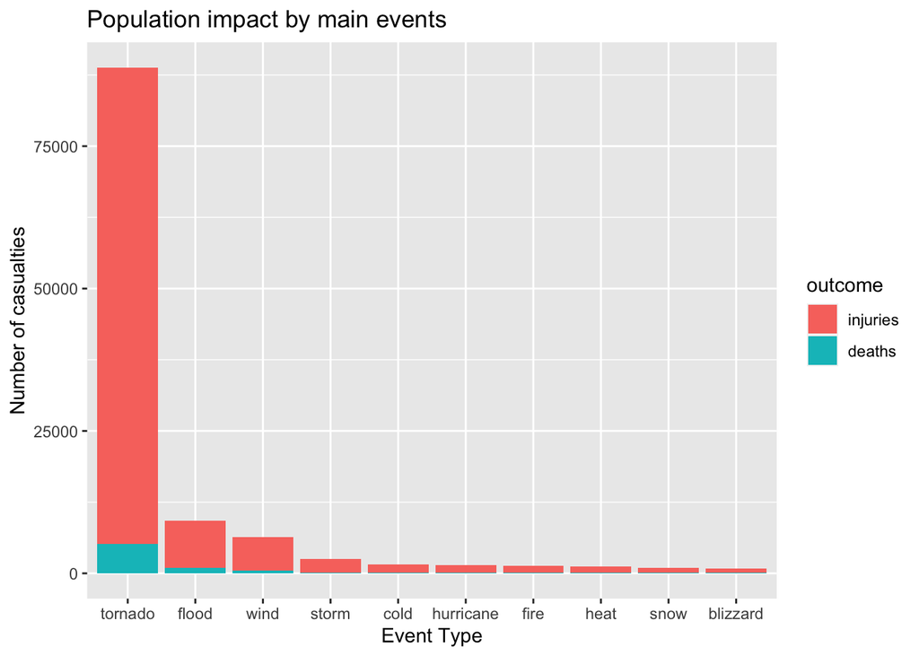

```r
output1_1 <- stormdata %>%
    group_by(EVTYPE) %>%
    summarise(injuries = sum(INJURIES), deaths = sum(FATALITIES), .groups = "keep") %>%
    arrange(desc(injuries)) %>% head(10)
output1_1 <- melt(output1_1, id = "EVTYPE")
names(output1_1) <- c("EVTYPE", "outcome", "value")
plot1_1 <- ggplot(output1_1, aes(fill = outcome, y = value, x = reorder(EVTYPE, -value))) +
    geom_bar(position = "stack", stat = "identity") +
    ggtitle("Population impact by main events") +
    xlab("Event Type") +
    ylab("Number of casualties")
decades <- floor((max(as.numeric(format(stormdata$BGN_DATE, format = "%Y"))) - min(as.numeric(format(stormdata$BGN_DATE, format = "%Y"))))/10)
top_events <- unlist(as.list(output1_1[1:10, "EVTYPE"]))
output1_2 <- stormdata %>%
    filter(EVTYPE %in% top_events) %>%
    group_by(EVTYPE) %>%
    summarise(incidence = floor(n()/decades), .groups = "keep") %>%
    arrange(desc(incidence)) %>% head(10)
plot1_2 <- ggplot(output1_2, aes(y = incidence, x = reorder(EVTYPE, -incidence), group = 1)) +
    geom_line() +
    ggtitle("Events incidence per decade") +
    xlab("Event Type") +
    ylab("Incidence per decade")
plot1_1
```

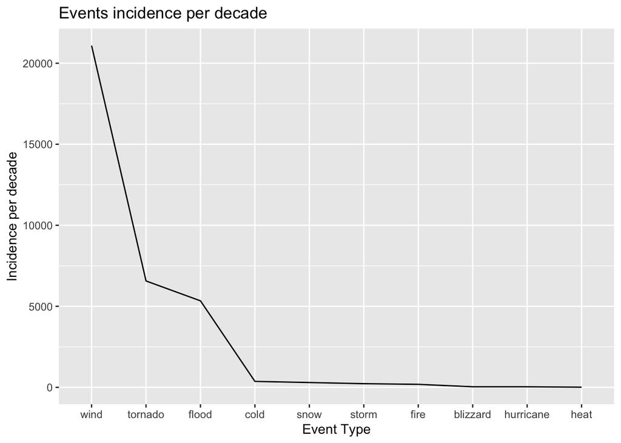

```r
plot1_2
```

Winds, tornadoes and floods are the most common incidents that happen.  
They are also the most impactful in terms of public health.  
If needed **resources should be prioritized for tornado**, being the 2nd most common incident, with the highest death tool and injuries of all events.

### Q2 - Economic impact of events types

**Across the United States, which types of events have the greatest economic consequences?**

First, let’s take a look at overall incidence and economic impact on each event type. The ecnomic impat is the sum of PROP + CROP DMG

```r
stormdata %>%
    group_by(EVTYPE) %>%
    summarise(damageBn = sum(DMGTOTALVALUE)/1e+09, n = n(), .groups = "keep") %>%
    arrange(desc(damageBn)) %>%
    head(5)
```

```
## # A tibble: 5 x 3
## # Groups:   EVTYPE [5]
##   EVTYPE    damageBn     n
##   <chr>        <dbl> <int>
## 1 flood        180.  32030
## 2 hurricane     90.3   213
## 3 storm         61.9  1360
## 4 tornado       59.0 39390
## 5 hail          19.1 26495
```

Let’s visualize the impact of total damage per event type

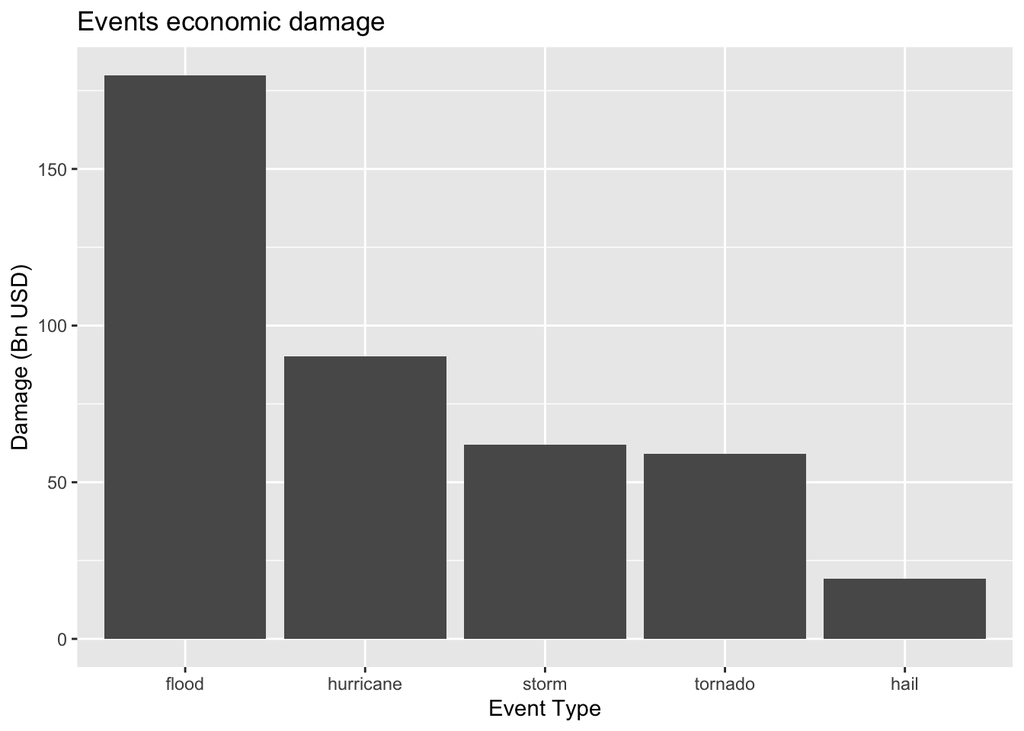

```r
output2 <- stormdata %>%
    group_by(EVTYPE) %>%
    summarise(damageBn = sum(DMGTOTALVALUE)/1e+09, n = n(), .groups = "keep") %>%
    arrange(desc(damageBn)) %>%
    head(5)
plot2 <- ggplot(output2, aes(y = damageBn, x = reorder(EVTYPE, -damageBn))) +
    geom_bar(stat = "identity") +
    ggtitle("Events economic damage") +
    xlab("Event Type") +
    ylab("Damage (Bn USD)")
plot2
```

In terms of economic damage, the most impactful event types are Floods, Hurricanes and Storms

If needed **resources should be prioritized to avoid floods**, being the most economic impactful event type

## Findings

In the united states, from 1950 to 2011, several atmospheric events happened but economic and health damage are concentrated in few event types